# 02-kickstarter-projects slides

### Agregacion por multiples columnas

Group by puede recibir un conjunto de columnas, por ejemplo volviendo a nuestro **anterior analisis por categoria y estado del proyecto.**

```python
grouped = projects_2017.groupby(['main_category','state'])
```

```python
grouped.count().head(100)
```

| main_category | state | index | name | category | currency | deadline | goal | launched | pledged | backers | country | usd pledged | usd_pledged_real | usd_goal_real | launched_datetime | year |
| --- | --- | --- | --- | --- | --- | --- | --- | --- | --- | --- | --- | --- | --- | --- | --- | --- |
| Art | canceled | 1667 | 1667 | 1667 | 1667 | 1667 | 1667 | 1667 | 1667 | 1667 | 1667 | 1667 | 1667 | 1667 | 1667 | 1667 |
|  | failed | 10953 | 10952 | 10953 | 10953 | 10953 | 10953 | 10953 | 10953 | 10953 | 10953 | 10953 | 10953 | 10953 | 10953 | 10953 |
|  | live | 124 | 124 | 124 | 124 | 124 | 124 | 124 | 124 | 124 | 124 | 124 | 124 | 124 | 124 | 124 |
|  | successful | 9496 | 9496 | 9496 | 9496 | 9496 | 9496 | 9496 | 9496 | 9496 | 9496 | 9496 | 9496 | 9496 | 9496 | 9496 |
|  | suspended | 71 | 71 | 71 | 71 | 71 | 71 | 71 | 71 | 71 | 71 | 71 | 71 | 71 | 71 | 71 |
| Comics | canceled | 673 | 673 | 673 | 673 | 673 | 673 | 673 | 673 | 673 | 673 | 673 | 673 | 673 | 673 | 673 |
|  | failed | 3339 | 3339 | 3339 | 3339 | 3339 | 3339 | 3339 | 3339 | 3339 | 3339 | 3339 | 3339 | 3339 | 3339 | 3339 |
|  | live | 59 | 59 | 59 | 59 | 59 | 59 | 59 | 59 | 59 | 59 | 59 | 59 | 59 | 59 | 59 |
|  | successful | 4820 | 4820 | 4820 | 4820 | 4820 | 4820 | 4820 | 4820 | 4820 | 4820 | 4820 | 4820 | 4820 | 4820 | 4820 |
|  | suspended | 19 | 19 | 19 | 19 | 19 | 19 | 19 | 19 | 19 | 19 | 19 | 19 | 19 | 19 | 19 |
| Crafts | canceled | 598 | 598 | 598 | 598 | 598 | 598 | 598 | 598 | 598 | 598 | 598 | 598 | 598 | 598 | 598 |
|  | failed | 4323 | 4323 | 4323 | 4323 | 4323 | 4323 | 4323 | 4323 | 4323 | 4323 | 4323 | 4323 | 4323 | 4323 | 4323 |
|  | live | 46 | 46 | 46 | 46 | 46 | 46 | 46 | 46 | 46 | 46 | 46 | 46 | 46 | 46 | 46 |
|  | successful | 1640 | 1640 | 1640 | 1640 | 1640 | 1640 | 1640 | 1640 | 1640 | 1640 | 1640 | 1640 | 1640 | 1640 | 1640 |
|  | suspended | 41 | 41 | 41 | 41 | 41 | 41 | 41 | 41 | 41 | 41 | 41 | 41 | 41 | 41 | 41 |
| Dance | canceled | 126 | 126 | 126 | 126 | 126 | 126 | 126 | 126 | 126 | 126 | 126 | 126 | 126 | 126 | 126 |
|  | failed | 993 | 993 | 993 | 993 | 993 | 993 | 993 | 993 | 993 | 993 | 993 | 993 | 993 | 993 | 993 |
|  | live | 12 | 12 | 12 | 12 | 12 | 12 | 12 | 12 | 12 | 12 | 12 | 12 | 12 | 12 | 12 |
|  | successful | 2088 | 2088 | 2088 | 2088 | 2088 | 2088 | 2088 | 2088 | 2088 | 2088 | 2088 | 2088 | 2088 | 2088 | 2088 |
|  | suspended | 9 | 9 | 9 | 9 | 9 | 9 | 9 | 9 | 9 | 9 | 9 | 9 | 9 | 9 | 9 |
| Design | canceled | 2857 | 2857 | 2857 | 2857 | 2857 | 2857 | 2857 | 2857 | 2857 | 2857 | 2857 | 2857 | 2857 | 2857 | 2857 |
|  | failed | 10804 | 10804 | 10804 | 10804 | 10804 | 10804 | 10804 | 10804 | 10804 | 10804 | 10804 | 10804 | 10804 | 10804 | 10804 |
|  | live | 171 | 171 | 171 | 171 | 171 | 171 | 171 | 171 | 171 | 171 | 171 | 171 | 171 | 171 | 171 |
|  | successful | 7681 | 7681 | 7681 | 7681 | 7681 | 7681 | 7681 | 7681 | 7681 | 7681 | 7681 | 7681 | 7681 | 7681 | 7681 |
|  | suspended | 177 | 176 | 177 | 177 | 177 | 177 | 177 | 177 | 177 | 177 | 177 | 177 | 177 | 177 | 177 |
| Fashion | canceled | 1811 | 1811 | 1811 | 1811 | 1811 | 1811 | 1811 | 1811 | 1811 | 1811 | 1811 | 1811 | 1811 | 1811 | 1811 |
|  | failed | 10416 | 10416 | 10416 | 10416 | 10416 | 10416 | 10416 | 10416 | 10416 | 10416 | 10416 | 10416 | 10416 | 10416 | 10416 |
|  | live | 148 | 148 | 148 | 148 | 148 | 148 | 148 | 148 | 148 | 148 | 148 | 148 | 148 | 148 | 148 |
|  | successful | 4120 | 4120 | 4120 | 4120 | 4120 | 4120 | 4120 | 4120 | 4120 | 4120 | 4120 | 4120 | 4120 | 4120 | 4120 |
|  | suspended | 89 | 89 | 89 | 89 | 89 | 89 | 89 | 89 | 89 | 89 | 89 | 89 | 89 | 89 | 89 |
| ... | ... | ... | ... | ... | ... | ... | ... | ... | ... | ... | ... | ... | ... | ... | ... | ... |
| Journalism | canceled | 374 | 374 | 374 | 374 | 374 | 374 | 374 | 374 | 374 | 374 | 374 | 374 | 374 | 374 | 374 |
|  | failed | 2311 | 2311 | 2311 | 2311 | 2311 | 2311 | 2311 | 2311 | 2311 | 2311 | 2311 | 2311 | 2311 | 2311 | 2311 |
|  | live | 21 | 21 | 21 | 21 | 21 | 21 | 21 | 21 | 21 | 21 | 21 | 21 | 21 | 21 | 21 |
|  | successful | 798 | 798 | 798 | 798 | 798 | 798 | 798 | 798 | 798 | 798 | 798 | 798 | 798 | 798 | 798 |
|  | suspended | 36 | 36 | 36 | 36 | 36 | 36 | 36 | 36 | 36 | 36 | 36 | 36 | 36 | 36 | 36 |
| Music | canceled | 2706 | 2706 | 2706 | 2706 | 2706 | 2706 | 2706 | 2706 | 2706 | 2706 | 2706 | 2706 | 2706 | 2706 | 2706 |
|  | failed | 18507 | 18507 | 18507 | 18507 | 18507 | 18507 | 18507 | 18507 | 18507 | 18507 | 18507 | 18507 | 18507 | 18507 | 18507 |
|  | live | 194 | 194 | 194 | 194 | 194 | 194 | 194 | 194 | 194 | 194 | 194 | 194 | 194 | 194 | 194 |
|  | successful | 21718 | 21718 | 21718 | 21718 | 21718 | 21718 | 21718 | 21718 | 21718 | 21718 | 21718 | 21718 | 21718 | 21718 | 21718 |
|  | suspended | 113 | 113 | 113 | 113 | 113 | 113 | 113 | 113 | 113 | 113 | 113 | 113 | 113 | 113 | 113 |
| Photography | canceled | 690 | 690 | 690 | 690 | 690 | 690 | 690 | 690 | 690 | 690 | 690 | 690 | 690 | 690 | 690 |
|  | failed | 4688 | 4688 | 4688 | 4688 | 4688 | 4688 | 4688 | 4688 | 4688 | 4688 | 4688 | 4688 | 4688 | 4688 | 4688 |
|  | live | 30 | 30 | 30 | 30 | 30 | 30 | 30 | 30 | 30 | 30 | 30 | 30 | 30 | 30 | 30 |
|  | successful | 2541 | 2541 | 2541 | 2541 | 2541 | 2541 | 2541 | 2541 | 2541 | 2541 | 2541 | 2541 | 2541 | 2541 | 2541 |
|  | suspended | 39 | 39 | 39 | 39 | 39 | 39 | 39 | 39 | 39 | 39 | 39 | 39 | 39 | 39 | 39 |
| Publishing | canceled | 2805 | 2805 | 2805 | 2805 | 2805 | 2805 | 2805 | 2805 | 2805 | 2805 | 2805 | 2805 | 2805 | 2805 | 2805 |
|  | failed | 18712 | 18712 | 18712 | 18712 | 18712 | 18712 | 18712 | 18712 | 18712 | 18712 | 18712 | 18712 | 18712 | 18712 | 18712 |
|  | live | 198 | 198 | 198 | 198 | 198 | 198 | 198 | 198 | 198 | 198 | 198 | 198 | 198 | 198 | 198 |
|  | successful | 9965 | 9965 | 9965 | 9965 | 9965 | 9965 | 9965 | 9965 | 9965 | 9965 | 9965 | 9965 | 9965 | 9965 | 9965 |
|  | suspended | 46 | 46 | 46 | 46 | 46 | 46 | 46 | 46 | 46 | 46 | 46 | 46 | 46 | 46 | 46 |
| Technology | canceled | 3049 | 3049 | 3049 | 3049 | 3049 | 3049 | 3049 | 3049 | 3049 | 3049 | 3049 | 3049 | 3049 | 3049 | 3049 |
|  | failed | 13335 | 13335 | 13335 | 13335 | 13335 | 13335 | 13335 | 13335 | 13335 | 13335 | 13335 | 13335 | 13335 | 13335 | 13335 |
|  | live | 202 | 202 | 202 | 202 | 202 | 202 | 202 | 202 | 202 | 202 | 202 | 202 | 202 | 202 | 202 |
|  | successful | 4723 | 4723 | 4723 | 4723 | 4723 | 4723 | 4723 | 4723 | 4723 | 4723 | 4723 | 4723 | 4723 | 4723 | 4723 |
|  | suspended | 247 | 247 | 247 | 247 | 247 | 247 | 247 | 247 | 247 | 247 | 247 | 247 | 247 | 247 | 247 |
| Theater | canceled | 475 | 475 | 475 | 475 | 475 | 475 | 475 | 475 | 475 | 475 | 475 | 475 | 475 | 475 | 475 |
|  | failed | 2973 | 2973 | 2973 | 2973 | 2973 | 2973 | 2973 | 2973 | 2973 | 2973 | 2973 | 2973 | 2973 | 2973 | 2973 |
|  | live | 29 | 29 | 29 | 29 | 29 | 29 | 29 | 29 | 29 | 29 | 29 | 29 | 29 | 29 | 29 |
|  | successful | 5221 | 5221 | 5221 | 5221 | 5221 | 5221 | 5221 | 5221 | 5221 | 5221 | 5221 | 5221 | 5221 | 5221 | 5221 |
|  | suspended | 11 | 11 | 11 | 11 | 11 | 11 | 11 | 11 | 11 | 11 | 11 | 11 | 11 | 11 | 11 |

75 rows × 15 columns

```python
grouped.index
```

```
<pandas.core.groupby.generic.SeriesGroupBy object at 0x144dbe908>
```

Inevitablemente al utilizar group by, vamos a estar creando un **MultiIndex** en las columnas, filas o ambas. Los DataFrames con MultiIndexes son mas dificiles de navegar y ocasionalmente tienen nombres de columnas mas confusos.

```python
by_main_category_state = projects_2017.groupby(['main_category','state'])\
    .agg({'backers':['mean','sum'],'pledged':'mean', 'goal':'mean'})
```

Al hacer esto, obtenemos una estructura con dos niveles de indices. Esto dificulta el acceso a los datos.

Es por eso que intentaremos simplificar la estructura, para ello intentemos entender como esta la informacion en cada nivel de la misma

```python
level0 = by_main_category_state.columns.get_level_values(0)
```

```python
level0
```

```
Index(['backers', 'backers', 'pledged', 'goal'], dtype='object')
```

```python
level1 = by_main_category_state.columns.get_level_values(1)
```

```python
level1
```

```
Index(['mean', 'sum', 'mean', 'mean'], dtype='object')
```

Podemos ver que tenemos multiples columnas que se llaman mean, cada una correspondiente a backers, pledged y goal respectivamente.

vamos a intentar reducir esta estructura, concatenando ambos niveles en el mismo nombre de columna

```python
by_main_category_state.columns = level0 + '_' + level1
```

```python
by_main_category_state.columns
```

```
Index(['backers_mean', 'backers_sum', 'pledged_mean', 'goal_mean'], dtype='object')
```

Podemos ver que todavia tenemos dos niveles pero esto podemos reducirlo realizando un `reset_index`

```python
by_main_category_state.reset_index()
```

|  | main_category | state | backers_mean | backers_sum | pledged_mean | goal_mean |
| --- | --- | --- | --- | --- | --- | --- |
| 0 | Art | canceled | 8.08 | 13468 | 520.37 | 42,709.40 |
| 1 | Art | failed | 9.12 | 99860 | 641.06 | 56,330.52 |
| 2 | Art | live | 16.99 | 2107 | 1,126.16 | 21,166.93 |
| 3 | Art | successful | 88.85 | 843718 | 6,919.10 | 4,522.81 |
| 4 | Art | suspended | 12.21 | 867 | 584.49 | 11,931.52 |
| 5 | Comics | canceled | 19.37 | 13033 | 904.36 | 12,757.82 |
| 6 | Comics | failed | 21.33 | 71208 | 1,036.00 | 48,072.56 |
| 7 | Comics | live | 61.24 | 3613 | 2,857.53 | 4,857.73 |
| 8 | Comics | successful | 243.02 | 1171337 | 12,193.53 | 5,639.63 |
| 9 | Comics | suspended | 5.05 | 96 | 449.58 | 23,336.63 |
| 10 | Crafts | canceled | 8.06 | 4818 | 462.75 | 13,170.08 |
| 11 | Crafts | failed | 6.19 | 26742 | 352.10 | 13,274.68 |
| 12 | Crafts | live | 8.00 | 368 | 739.02 | 9,046.80 |
| 13 | Crafts | successful | 101.46 | 166389 | 5,850.09 | 2,989.25 |
| 14 | Crafts | suspended | 6.29 | 258 | 264.85 | 11,838.61 |
| 15 | Dance | canceled | 6.65 | 838 | 599.27 | 37,615.79 |
| 16 | Dance | failed | 10.18 | 10113 | 639.16 | 15,388.37 |
| 17 | Dance | live | 15.58 | 187 | 1,015.00 | 5,170.83 |
| 18 | Dance | successful | 65.25 | 136249 | 5,365.26 | 4,745.96 |
| 19 | Dance | suspended | 4.44 | 40 | 374.67 | 19,344.44 |
| 20 | Design | canceled | 44.93 | 128353 | 4,712.97 | 77,952.12 |
| 21 | Design | failed | 32.39 | 349946 | 2,789.19 | 55,662.13 |
| 22 | Design | live | 304.95 | 52147 | 20,687.70 | 24,692.53 |
| 23 | Design | successful | 687.13 | 5277876 | 68,928.17 | 16,008.04 |
| 24 | Design | suspended | 248.59 | 44000 | 18,439.35 | 27,185.45 |
| 25 | Fashion | canceled | 12.78 | 23152 | 1,331.48 | 22,638.92 |
| 26 | Fashion | failed | 9.91 | 103257 | 816.06 | 27,910.28 |
| 27 | Fashion | live | 28.78 | 4259 | 2,718.42 | 20,973.01 |
| 28 | Fashion | successful | 239.92 | 988463 | 21,631.64 | 9,165.04 |
| 29 | Fashion | suspended | 58.13 | 5174 | 4,414.80 | 10,980.30 |
| ... | ... | ... | ... | ... | ... | ... |
| 45 | Journalism | canceled | 5.40 | 2019 | 326.36 | 29,929.43 |
| 46 | Journalism | failed | 8.73 | 20166 | 643.65 | 105,165.10 |
| 47 | Journalism | live | 25.86 | 543 | 3,060.12 | 17,018.81 |
| 48 | Journalism | successful | 149.98 | 119682 | 10,390.67 | 8,226.53 |
| 49 | Journalism | suspended | 1.97 | 71 | 42.36 | 2,794,553.89 |
| 50 | Music | canceled | 7.44 | 20138 | 512.00 | 35,826.24 |
| 51 | Music | failed | 9.61 | 177760 | 653.79 | 24,211.02 |
| 52 | Music | live | 26.46 | 5134 | 3,670.72 | 41,260.11 |
| 53 | Music | successful | 103.89 | 2256182 | 7,481.14 | 5,840.72 |
| 54 | Music | suspended | 4.53 | 512 | 384.66 | 41,007.33 |
| 55 | Photography | canceled | 6.81 | 4699 | 553.95 | 26,724.92 |
| 56 | Photography | failed | 9.83 | 46090 | 708.03 | 14,087.27 |
| 57 | Photography | live | 39.10 | 1173 | 6,278.53 | 10,296.63 |
| 58 | Photography | successful | 105.58 | 268288 | 9,979.34 | 6,426.16 |
| 59 | Photography | suspended | 9.85 | 384 | 259.46 | 17,117.26 |
| 60 | Publishing | canceled | 7.73 | 21695 | 540.26 | 75,730.94 |
| 61 | Publishing | failed | 9.99 | 186847 | 625.03 | 25,364.79 |
| 62 | Publishing | live | 35.76 | 7081 | 2,073.15 | 13,478.59 |
| 63 | Publishing | successful | 157.40 | 1568449 | 9,333.08 | 5,804.18 |
| 64 | Publishing | suspended | 9.41 | 433 | 554.82 | 2,193,376.39 |
| 65 | Technology | canceled | 37.45 | 114184 | 5,552.12 | 103,013.48 |
| 66 | Technology | failed | 22.30 | 297365 | 2,551.88 | 124,095.61 |
| 67 | Technology | live | 151.48 | 30599 | 16,707.58 | 54,501.09 |
| 68 | Technology | successful | 796.37 | 3761246 | 104,317.68 | 27,457.03 |
| 69 | Technology | suspended | 330.66 | 81673 | 36,002.97 | 210,846.18 |
| 70 | Theater | canceled | 13.51 | 6415 | 1,407.74 | 114,751.53 |
| 71 | Theater | failed | 12.25 | 36434 | 1,035.45 | 54,260.62 |
| 72 | Theater | live | 30.76 | 892 | 3,793.40 | 11,427.59 |
| 73 | Theater | successful | 75.54 | 394405 | 6,422.14 | 5,562.83 |
| 74 | Theater | suspended | 4.64 | 51 | 105.27 | 34,531.45 |

75 rows × 6 columns

Si queremos realizar el cambio de forma permanente en el DataFrame debemos realizarlo inPlace

```python
by_main_category_state.reset_index(inplace=True)
```

```python
by_main_category_state
```

|  | main_category | state | backers_mean | backers_sum | pledged_mean | goal_mean |
| --- | --- | --- | --- | --- | --- | --- |
| 0 | Art | canceled | 8.08 | 13468 | 520.37 | 42,709.40 |
| 1 | Art | failed | 9.12 | 99860 | 641.06 | 56,330.52 |
| 2 | Art | live | 16.99 | 2107 | 1,126.16 | 21,166.93 |
| 3 | Art | successful | 88.85 | 843718 | 6,919.10 | 4,522.81 |
| 4 | Art | suspended | 12.21 | 867 | 584.49 | 11,931.52 |
| 5 | Comics | canceled | 19.37 | 13033 | 904.36 | 12,757.82 |
| 6 | Comics | failed | 21.33 | 71208 | 1,036.00 | 48,072.56 |
| 7 | Comics | live | 61.24 | 3613 | 2,857.53 | 4,857.73 |
| 8 | Comics | successful | 243.02 | 1171337 | 12,193.53 | 5,639.63 |
| 9 | Comics | suspended | 5.05 | 96 | 449.58 | 23,336.63 |
| 10 | Crafts | canceled | 8.06 | 4818 | 462.75 | 13,170.08 |
| 11 | Crafts | failed | 6.19 | 26742 | 352.10 | 13,274.68 |
| 12 | Crafts | live | 8.00 | 368 | 739.02 | 9,046.80 |
| 13 | Crafts | successful | 101.46 | 166389 | 5,850.09 | 2,989.25 |
| 14 | Crafts | suspended | 6.29 | 258 | 264.85 | 11,838.61 |
| 15 | Dance | canceled | 6.65 | 838 | 599.27 | 37,615.79 |
| 16 | Dance | failed | 10.18 | 10113 | 639.16 | 15,388.37 |
| 17 | Dance | live | 15.58 | 187 | 1,015.00 | 5,170.83 |
| 18 | Dance | successful | 65.25 | 136249 | 5,365.26 | 4,745.96 |
| 19 | Dance | suspended | 4.44 | 40 | 374.67 | 19,344.44 |
| 20 | Design | canceled | 44.93 | 128353 | 4,712.97 | 77,952.12 |
| 21 | Design | failed | 32.39 | 349946 | 2,789.19 | 55,662.13 |
| 22 | Design | live | 304.95 | 52147 | 20,687.70 | 24,692.53 |
| 23 | Design | successful | 687.13 | 5277876 | 68,928.17 | 16,008.04 |
| 24 | Design | suspended | 248.59 | 44000 | 18,439.35 | 27,185.45 |
| 25 | Fashion | canceled | 12.78 | 23152 | 1,331.48 | 22,638.92 |
| 26 | Fashion | failed | 9.91 | 103257 | 816.06 | 27,910.28 |
| 27 | Fashion | live | 28.78 | 4259 | 2,718.42 | 20,973.01 |
| 28 | Fashion | successful | 239.92 | 988463 | 21,631.64 | 9,165.04 |
| 29 | Fashion | suspended | 58.13 | 5174 | 4,414.80 | 10,980.30 |
| ... | ... | ... | ... | ... | ... | ... |
| 45 | Journalism | canceled | 5.40 | 2019 | 326.36 | 29,929.43 |
| 46 | Journalism | failed | 8.73 | 20166 | 643.65 | 105,165.10 |
| 47 | Journalism | live | 25.86 | 543 | 3,060.12 | 17,018.81 |
| 48 | Journalism | successful | 149.98 | 119682 | 10,390.67 | 8,226.53 |
| 49 | Journalism | suspended | 1.97 | 71 | 42.36 | 2,794,553.89 |
| 50 | Music | canceled | 7.44 | 20138 | 512.00 | 35,826.24 |
| 51 | Music | failed | 9.61 | 177760 | 653.79 | 24,211.02 |
| 52 | Music | live | 26.46 | 5134 | 3,670.72 | 41,260.11 |
| 53 | Music | successful | 103.89 | 2256182 | 7,481.14 | 5,840.72 |
| 54 | Music | suspended | 4.53 | 512 | 384.66 | 41,007.33 |
| 55 | Photography | canceled | 6.81 | 4699 | 553.95 | 26,724.92 |
| 56 | Photography | failed | 9.83 | 46090 | 708.03 | 14,087.27 |
| 57 | Photography | live | 39.10 | 1173 | 6,278.53 | 10,296.63 |
| 58 | Photography | successful | 105.58 | 268288 | 9,979.34 | 6,426.16 |
| 59 | Photography | suspended | 9.85 | 384 | 259.46 | 17,117.26 |
| 60 | Publishing | canceled | 7.73 | 21695 | 540.26 | 75,730.94 |
| 61 | Publishing | failed | 9.99 | 186847 | 625.03 | 25,364.79 |
| 62 | Publishing | live | 35.76 | 7081 | 2,073.15 | 13,478.59 |
| 63 | Publishing | successful | 157.40 | 1568449 | 9,333.08 | 5,804.18 |
| 64 | Publishing | suspended | 9.41 | 433 | 554.82 | 2,193,376.39 |
| 65 | Technology | canceled | 37.45 | 114184 | 5,552.12 | 103,013.48 |
| 66 | Technology | failed | 22.30 | 297365 | 2,551.88 | 124,095.61 |
| 67 | Technology | live | 151.48 | 30599 | 16,707.58 | 54,501.09 |
| 68 | Technology | successful | 796.37 | 3761246 | 104,317.68 | 27,457.03 |
| 69 | Technology | suspended | 330.66 | 81673 | 36,002.97 | 210,846.18 |
| 70 | Theater | canceled | 13.51 | 6415 | 1,407.74 | 114,751.53 |
| 71 | Theater | failed | 12.25 | 36434 | 1,035.45 | 54,260.62 |
| 72 | Theater | live | 30.76 | 892 | 3,793.40 | 11,427.59 |
| 73 | Theater | successful | 75.54 | 394405 | 6,422.14 | 5,562.83 |
| 74 | Theater | suspended | 4.64 | 51 | 105.27 | 34,531.45 |

75 rows × 6 columns

Por ultimo es importante notar que dependiendo del nivel de agrupamiento podriamos contar con multiples niveles

```python
# por ejemplo agrupando por main_category, category (sub categoria) y state
projects_2017.groupby(['main_category','category','state']).agg({'backers':['mean','sum'],'pledged':'mean', 'goal':'mean'})
```

| main_category | category | state | backers mean | backers sum | pledged mean | goal mean |
| --- | --- | --- | --- | --- | --- | --- |
| Art | Art | canceled | 7.41 | 3794 | 439.67 | 42,464.77 |
|  |  | failed | 9.56 | 30241 | 672.17 | 90,218.96 |
|  |  | live | 10.82 | 476 | 1,136.84 | 8,975.45 |
|  |  | successful | 89.93 | 247315 | 7,481.84 | 5,153.35 |
|  |  | suspended | 18.00 | 504 | 416.64 | 10,302.82 |
|  | Ceramics | canceled | 2.75 | 55 | 193.45 | 22,080.00 |
|  |  | failed | 8.60 | 1006 | 695.89 | 19,640.09 |
|  |  | live | 5.00 | 10 | 207.00 | 18,500.00 |
|  |  | successful | 111.13 | 12002 | 11,395.04 | 7,935.55 |
|  | Conceptual Art | canceled | 6.35 | 419 | 329.06 | 11,215.95 |
|  |  | failed | 7.81 | 3344 | 454.39 | 17,375.68 |
|  |  | live | 14.40 | 72 | 532.20 | 220,300.00 |
|  |  | successful | 58.51 | 18371 | 3,500.97 | 2,922.86 |
|  |  | suspended | 5.75 | 23 | 60.00 | 925.00 |
|  | Digital Art | canceled | 7.86 | 943 | 567.99 | 22,217.79 |
|  |  | failed | 6.28 | 3575 | 314.14 | 9,366.85 |
|  |  | live | 28.57 | 200 | 370.43 | 7,035.71 |
|  |  | successful | 92.22 | 26652 | 5,607.34 | 3,191.84 |
|  |  | suspended | 1.00 | 1 | 1.00 | 50.00 |
|  | Illustration | canceled | 9.76 | 1532 | 501.28 | 11,197.99 |
|  |  | failed | 10.98 | 9588 | 528.57 | 5,289.78 |
|  |  | live | 35.44 | 886 | 1,770.76 | 2,254.00 |
|  |  | successful | 117.48 | 135333 | 6,256.71 | 2,815.97 |
|  |  | suspended | 0.20 | 1 | 1.00 | 4,130.00 |
|  | Installations | canceled | 11.95 | 251 | 1,400.37 | 9,205.71 |
|  |  | failed | 13.63 | 1731 | 1,363.28 | 430,946.28 |
|  |  | live | 3.33 | 10 | 471.00 | 37,333.33 |
|  |  | successful | 92.22 | 16876 | 8,634.23 | 7,116.57 |
|  |  | suspended | 2.33 | 7 | 35.67 | 2,678.67 |
|  | Mixed Media | canceled | 5.86 | 949 | 426.21 | 35,260.64 |
| ... | ... | ... | ... | ... | ... | ... |
| Theater | Experimental | live | 38.00 | 114 | 7,160.67 | 27,166.67 |
|  |  | successful | 84.25 | 12638 | 6,070.83 | 5,082.87 |
|  | Festivals | canceled | 9.45 | 208 | 772.23 | 226,702.45 |
|  |  | failed | 6.36 | 751 | 407.77 | 65,495.42 |
|  |  | live | 0.00 | 0 | 0.00 | 70,000.00 |
|  |  | successful | 71.90 | 11144 | 6,105.75 | 5,389.34 |
|  |  | suspended | 0.00 | 0 | 0.00 | 80.00 |
|  | Immersive | canceled | 5.59 | 95 | 352.35 | 114,135.59 |
|  |  | failed | 10.79 | 971 | 789.22 | 483,010.46 |
|  |  | live | 26.00 | 26 | 1,106.00 | 1,100.00 |
|  |  | successful | 93.22 | 10814 | 10,263.96 | 7,983.21 |
|  |  | suspended | 1.50 | 3 | 65.50 | 8,500.00 |
|  | Musical | canceled | 4.70 | 221 | 356.45 | 68,604.49 |
|  |  | failed | 11.36 | 2941 | 1,213.11 | 57,694.62 |
|  |  | live | 37.40 | 187 | 8,611.20 | 11,200.00 |
|  |  | successful | 96.74 | 31635 | 9,784.43 | 7,937.79 |
|  |  | suspended | 5.00 | 5 | 90.00 | 250.00 |
|  | Plays | canceled | 4.48 | 224 | 329.52 | 17,421.00 |
|  |  | failed | 7.31 | 2523 | 581.64 | 26,595.45 |
|  |  | live | 42.00 | 420 | 2,602.86 | 9,290.00 |
|  |  | successful | 63.43 | 30131 | 5,622.47 | 5,047.10 |
|  | Spaces | canceled | 33.71 | 472 | 6,562.93 | 2,367,078.57 |
|  |  | failed | 14.26 | 984 | 1,471.39 | 309,614.78 |
|  |  | live | 36.00 | 36 | 7,410.00 | 5,000.00 |
|  |  | successful | 210.15 | 16602 | 23,197.50 | 19,086.89 |
|  | Theater | canceled | 16.75 | 5124 | 1,690.81 | 20,937.56 |
|  |  | failed | 13.99 | 27808 | 1,163.78 | 27,370.55 |
|  |  | live | 12.00 | 60 | 874.20 | 2,740.00 |
|  |  | successful | 71.60 | 278601 | 5,778.49 | 5,074.41 |
|  |  | suspended | 6.14 | 43 | 133.86 | 51,788.00 |

799 rows × 4 columns

## Filtrado (Filtering)

```python
projects_2017.groupby('year')['backers'].agg('mean') # notar que se obteniene una Serie
```

```
year
1970                   0.00
2009                  32.93
2010                  38.68
2011                  53.23
2012                 104.19
2013                 147.47
2014                 102.07
2015                 111.87
2016                 141.70
2017                 144.52
2018                   8.59
Name: backers, dtype: float64
```

```python
per_year = projects_2017.groupby('year')
per_year.ngroups
```

```
11
```

```python
def check_backers_threshold(df, threshold):
    return df['backers'].mean() >= threshold
```

```python
per_year_filtered = per_year.filter(check_backers_threshold, threshold=100)
```

```python
per_year_filtered.groupby('year')['backers'].agg('mean')
```

```
year
2012                 104.19
2013                 147.47
2014                 102.07
2015                 111.87
2016                 141.70
2017                 144.52
Name: backers, dtype: float64
```

## Transform

```python
#calculamos el porcentaje que representa dentro de un año, categoria principal y categoria
percentages = projects_2017.groupby(['year','main_category','category'])['goal','pledged']\
                    .transform((lambda x: (x * 100) / x.sum()))
percentages
```

| ID | goal | pledged |
| --- | --- | --- |
| 1000003930 | 0.62 | 0.16 |
| 1000004038 | 0.04 | 0.00 |
| 1000007540 | 0.02 | 0.00 |
| 1000011046 | 0.03 | 0.03 |
| 1000014025 | 0.20 | 2.43 |
| 1000023410 | 0.00 | 0.01 |
| 1000030581 | 0.05 | 0.02 |
| 1000034518 | 0.14 | 0.01 |
| 100004195 | 0.04 | 0.03 |
| 100005484 | 0.23 | 0.28 |
| 1000055792 | 0.05 | 0.00 |
| 1000056157 | 0.48 | 0.00 |
| 1000064368 | 0.01 | 0.01 |
| 1000064918 | 0.07 | 0.03 |
| 1000068480 | 0.08 | 0.03 |
| 1000070642 | 0.00 | 0.00 |
| 1000071625 | 0.01 | 0.02 |
| 1000072011 | 0.07 | 0.22 |
| 1000082254 | 0.04 | 0.02 |
| 1000091520 | 0.00 | 0.02 |
| 1000102741 | 0.28 | 0.91 |
| 100011318 | 0.73 | 2.10 |
| 1000117861 | 0.00 | 0.04 |
| 1000120287 | 0.25 | 0.06 |
| 100012079 | 0.04 | 0.18 |
| 1000129669 | 0.04 | 0.02 |
| 1000131947 | 0.06 | 0.18 |
| 1000132945 | 0.01 | 0.07 |
| 1000134913 | 0.11 | 0.00 |
| 1000146991 | 0.23 | 0.36 |
| ... | ... | ... |
| 999796570 | 0.11 | 0.75 |
| 999799441 | 0.10 | 0.20 |
| 999800713 | 0.03 | 0.11 |
| 999801167 | 0.07 | 0.04 |
| 999801508 | 0.01 | 0.03 |
| 999810803 | 0.21 | 0.00 |
| 999814955 | 0.03 | 0.06 |
| 999832803 | 0.34 | 0.53 |
| 99984851 | 0.01 | 0.00 |
| 999865831 | 0.09 | 0.21 |
| 999867839 | 0.17 | 0.37 |
| 99987261 | 0.00 | 0.00 |
| 999878813 | 0.37 | 0.66 |
| 999880710 | 0.03 | 0.00 |
| 999884445 | 0.02 | 0.13 |
| 999893629 | 0.00 | 0.01 |
| 999931480 | 0.17 | 0.00 |
| 999934908 | 0.00 | 0.01 |
| 999943841 | 0.01 | 0.07 |
| 999950812 | 0.03 | 0.03 |
| 999955533 | 0.00 | 0.00 |
| 999963618 | 0.01 | 0.01 |
| 99996661 | 0.01 | 0.00 |
| 999972264 | 0.00 | 0.00 |
| 999975836 | 0.15 | 0.01 |
| 999976400 | 0.03 | 0.00 |
| 999977640 | 0.00 | 0.00 |
| 999986353 | 0.28 | 0.00 |
| 999987933 | 0.01 | 0.00 |
| 999988282 | 0.10 | 0.11 |

292627 rows × 2 columns

```python
projects_2017.shape
```

```
(292627, 17)
```

## Apply

```python
from collections import OrderedDict

def perform_stats(df):
    # lo usamos para preservar el orden de insercion
    data = OrderedDict()

    data['money_to_reach_goal'] = df['pledged'] - df['goal']
    data['count'] = len(df)

    return pd.Series(data)
```

```python
result = projects_2017.groupby(['main_category','category']).apply(perform_stats)
```

```python
result
```

| main_category | category | money_to_reach_goal | count |
| --- | --- | --- | --- |
| Art | Art | ID 1000082254 -7,497.00 100025241... | 6498 |
|  | Ceramics | ID 1000082254 1,386.00 100025241... | 247 |
|  | Conceptual Art | ID 1000082254 -7,700.00 100025241... | 817 |
|  | Digital Art | ID 1000082254 5.33 100025241... | 986 |
|  | Illustration | ID 1000082254 -2,983.00 100025241... | 2212 |
|  | Installations | ID 1000082254 -1,000.00 100025241... | 337 |
|  | Mixed Media | ID 1000082254 -2,000.00 100025241... | 2257 |
|  | Painting | ID 1000082254 262.57 100025241... | 2622 |
|  | Performance Art | ID 1000082254 -23,750.00 100025241... | 1845 |
|  | Public Art | ID 1000082254 -23,605.00 100025241... | 2632 |
|  | Sculpture | ID 1000082254 -4,948.00 100025241... | 1532 |
|  | Textiles | ID 1000082254 -4,670.00 100025241... | 187 |
|  | Video Art | ID 1000082254 5,249.00 100025241... | 139 |
| Comics | Anthologies | ID 1000082254 2,357.00 100025241... | 307 |
|  | Comic Books | ID 1000082254 -1,105.00 100025241... | 2105 |
|  | Comics | ID 1000082254 526.66 100025241... | 4448 |
|  | Events | ID 1000082254 519.00 100025241... | 119 |
|  | Graphic Novels | ID 1000082254 -2,831.00 100025241... | 1418 |
|  | Webcomics | ID 1000082254 -13,644.00 100025241... | 513 |
| Crafts | Candles | ID 1000082254 -1,000.00 100025241... | 337 |
|  | Crafts | ID 1000082254 -5,000.00 100025241... | 3567 |
|  | Crochet | ID 1000082254 -175.00 100025241... | 114 |
|  | DIY | ID 1000082254 -2,730.00 100025241... | 902 |
|  | Embroidery | ID 1000082254 29.00 100025241... | 72 |
|  | Glass | ID 1000082254 -7,140.00 100025241... | 113 |
|  | Knitting | ID 1000082254 25.00 100025241... | 122 |
|  | Letterpress | ID 1000082254 92.00 100025241... | 30 |
|  | Pottery | ID 1000082254 -4,668.00 100025241... | 59 |
|  | Printing | ID 1000082254 -1,094.00 100025241... | 152 |
|  | Quilts | ID 1000082254 -28,843.00 100025241... | 70 |
| ... | ... | ... | ... |
| Publishing | Poetry | ID 1000082254 -1,675.00 100025241... | 1158 |
|  | Publishing | ID 1000082254 165.00 100025241... | 4202 |
|  | Radio & Podcasts | ID 1000082254 55.00 100025241... | 774 |
|  | Translations | ID 1000082254 170.00 100025241... | 79 |
|  | Young Adult | ID 1000082254 25.00 100025241... | 613 |
|  | Zines | ID 1000082254 517.00 100025241... | 221 |
| Technology | 3D Printing | ID 1000082254 93,923.50 100025241... | 407 |
|  | Apps | ID 1000082254 -8,500.00 100025241... | 3910 |
|  | Camera Equipment | ID 1000082254 8,498.00 100025241... | 301 |
|  | DIY Electronics | ID 1000082254 13,447.00 100025241... | 555 |
|  | Fabrication Tools | ID 1000082254 0.00 100025241... | 155 |
|  | Flight | ID 1000082254 -7,145.00 100025241... | 293 |
|  | Gadgets | ID 1000082254 -84,970.00 100025241... | 2035 |
|  | Hardware | ID 1000082254 -5,980.00 100025241... | 2700 |
|  | Makerspaces | ID 1000082254 -1,604.00 100025241... | 161 |
|  | Robots | ID 1000082254 -69,256.00 100025241... | 414 |
|  | Software | ID 1000082254 -97,999.00 100025241... | 2052 |
|  | Sound | ID 1000082254 202,673.00 100025241... | 429 |
|  | Space Exploration | ID 1000082254 35.00 100025241... | 223 |
|  | Technology | ID 1000082254 -159,229.00 100025241... | 4754 |
|  | Wearables | ID 1000082254 -149,410.00 100025241... | 848 |
|  | Web | ID 1000082254 -99,859.00 100025241... | 2319 |
| Theater | Comedy | ID 1000082254 2.00 100025241... | 53 |
|  | Experimental | ID 1000082254 0.00 100025241... | 254 |
|  | Festivals | ID 1000082254 657.01 100025241... | 297 |
|  | Immersive | ID 1000082254 -3,119.82 100025241... | 226 |
|  | Musical | ID 1000082254 100.00 100025241... | 639 |
|  | Plays | ID 1000082254 1.00 100025241... | 880 |
|  | Spaces | ID 1000082254 -46,967.00 100025241... | 163 |
|  | Theater | ID 1000082254 -2,850.00 100025241... | 6197 |

170 rows × 2 columns

## Analizando la distribucion de variables

Un primer analisis que podemos comenzar a realizar como parte de nuestro analisis exploratorio es intentar comprender la distribucion los distintos valores por cada columna o feature que tenemos en nuestro data frame que queramos analizar.

Entendemos como distribucion a la cantidad de veces que la variable toma determinados valores.

Por lo analizado anteriormente mediante el describe dado que **hay un gran rango de valores posibles para visualizar no vamos a poder realizar en la escala normal** que tienen los datos, es por eso que los llevaremos a analizar **a escala logaritmica**, para poder graficar.

Tener en cuenta que en una escala logarítmica, una diferencia igual en orden de magnitud se representa por una distancia igual. La media geométrica de dos números está a medio camino entre los números y esto facilita graficar.

**IMPORTANTE:** Debemos ser cuidadosos con las conclusiones que obtengamos de analizar bajo la escala logaritmica, dado que su utilizacion hace compleja el analisis.

```python
projects_2017.describe()
```

|  | index | goal | pledged | backers | usd pledged | usd_pledged_real | usd_goal_real | year |
| --- | --- | --- | --- | --- | --- | --- | --- | --- |
| count | 292,627.00 | 292,627.00 | 292,627.00 | 292,627.00 | 292,627.00 | 292,627.00 | 292,627.00 | 292,627.00 |
| mean | 189,373.81 | 44,034.97 | 9,670.19 | 113.08 | 7,677.88 | 9,670.19 | 44,034.97 | 2,013.94 |
| std | 109,335.34 | 1,108,371.98 | 99,329.42 | 985.72 | 86,410.07 | 99,329.42 | 1,108,371.98 | 1.98 |
| min | 1.00 | 0.01 | 0.00 | 0.00 | 0.00 | 0.00 | 0.01 | 1,970.00 |
| 25% | 94,722.50 | 2,000.00 | 41.00 | 2.00 | 25.00 | 41.00 | 2,000.00 | 2,012.00 |
| 50% | 189,251.00 | 5,250.00 | 725.00 | 14.00 | 510.00 | 725.00 | 5,250.00 | 2,014.00 |
| 75% | 284,081.50 | 15,000.00 | 4,370.00 | 60.00 | 3,424.00 | 4,370.00 | 15,000.00 | 2,015.00 |
| max | 378,660.00 | 100,000,000.00 | 20,338,986.27 | 219,382.00 | 20,338,986.27 | 20,338,986.27 | 100,000,000.00 | 2,018.00 |

```
Text(0,0.5,'Frecuencia')
```

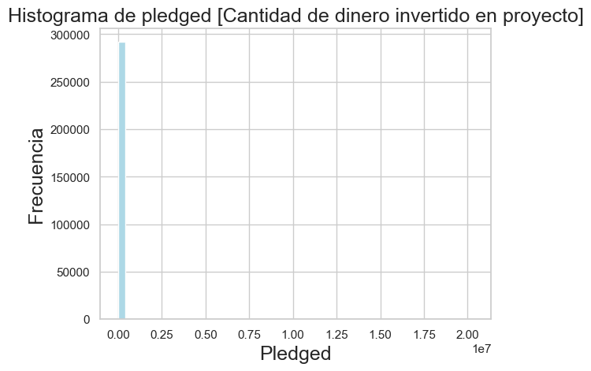

```python
# es importante que el grafico tenga un correcto titulo y valores descriptivos en barras
# https://matplotlib.org/api/_as_gen/matplotlib.pyplot.hist.html
g = projects_2017["pledged"].plot.hist(bins=50, color='lightblue')
g.set_title("Histograma de pledged [Cantidad de dinero invertido en proyecto]", fontsize=18)
g.set_xlabel("Pledged",fontsize=18)
g.set_ylabel("Frecuencia", fontsize=18)
```

```python
# creamos nuevas columnas en escala logaritmica
projects_2017["pledged_log"] = np.log(projects_2017["pledged"]+1)
projects_2017["goal_log"] = np.log(projects_2017["goal"]+1)
```

### Histograma

Un histograma sirve para mostrar la distribucion de una determinada variable. Para construirlo hacen falta dos parametros: la variable en cuestion que tiene que ser numerica (continua o discreta) y el ancho que van a tener las columnas del histograma. Este valor se fija en matplotlib con el valor de bins, que indica cuanto discretizamos los intervalos.

```
Text(0,0.5,'Frecuencia')
```

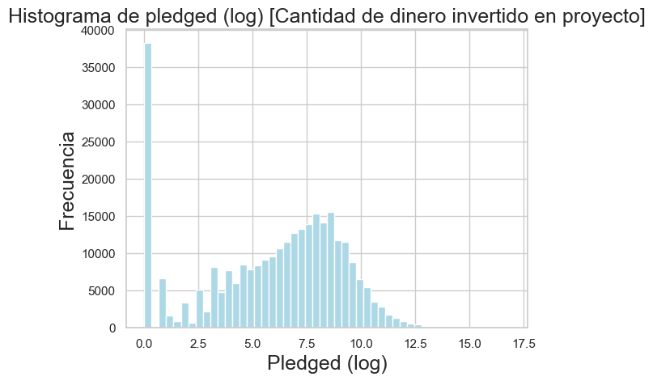

```python
# es importante que el grafico tenga un correcto titulo y valores descriptivos en barras
# https://matplotlib.org/api/_as_gen/matplotlib.pyplot.hist.html
g = projects_2017["pledged_log"].plot.hist(bins=50, color='lightblue')
g.set_title("Histograma de pledged (log) [Cantidad de dinero invertido en proyecto]", fontsize=18)
g.set_xlabel("Pledged (log)",fontsize=18)
g.set_ylabel("Frecuencia", fontsize=18)
```

```
Text(0,0.5,'Frecuencia')
```

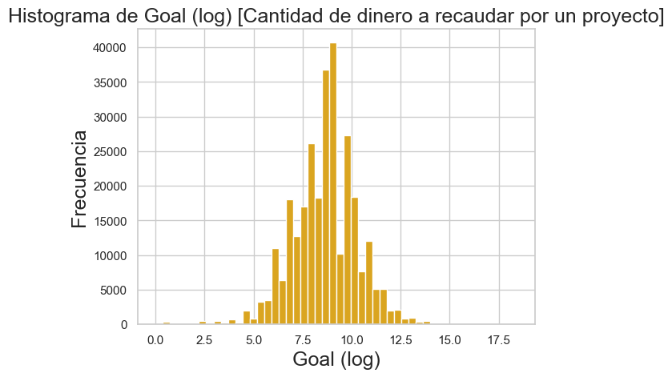

```python
g = projects_2017["goal_log"].plot.hist(bins=50, color='goldenrod')
g.set_title("Histograma de Goal (log) [Cantidad de dinero a recaudar por un proyecto]", fontsize=18)
g.set_xlabel("Goal (log)",fontsize=18)
g.set_ylabel("Frecuencia", fontsize=18)
```

### Density Plot

Un plot de densidad es una version continua de un histograma (no es necesario indicar el tamaño de los bins). Lo que se muestra es como se distribuye la densidad de la variable numerica a lo largo de todos sus valores posibles.

```
Text(0,0.5,'Densidad')
```

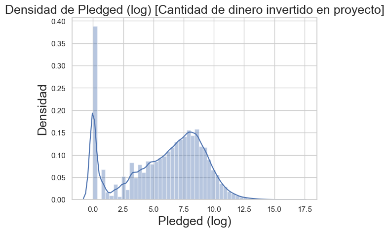

```python
# https://seaborn.pydata.org/generated/seaborn.distplot.html
g = sns.distplot(projects_2017["pledged_log"])
g.set_title("Densidad de Pledged (log) [Cantidad de dinero invertido en proyecto]", fontsize=18)
g.set_xlabel("Pledged (log)",fontsize=18)
g.set_ylabel("Densidad", fontsize=18)
```

```
Text(0,0.5,'Densidad')
```

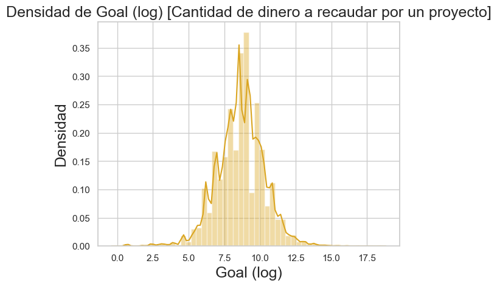

```python
g = sns.distplot(projects_2017["goal_log"], color='goldenrod')
g.set_title("Densidad de Goal (log) [Cantidad de dinero a recaudar por un proyecto]", fontsize=18)
g.set_xlabel("Goal (log)",fontsize=18)
g.set_ylabel("Densidad", fontsize=18)
```

## Overlaid Histogram

Una forma de comparar distribuciones sobre una misma base es realizar un overlay de distintos histogramas.

```
Text(0,0.5,'Frecuencia')
```

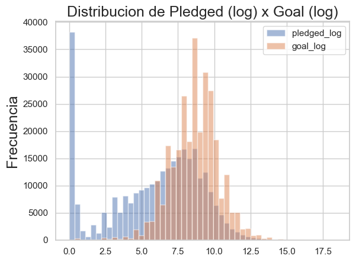

```python
# ambos histogramas juntos
g = projects_2017[["pledged_log","goal_log"]].plot.hist(bins=50,alpha=0.5)
g.set_title("Distribucion de Pledged (log) x Goal (log)", fontsize=18)
g.set_ylabel("Frecuencia", fontsize=18)
```

## Overlaid Density Plots

O tambien se pueden analizar directamente comparando sus densidades

```
Text(0.5,1,'Pledged x Goal cross distribuition')
```

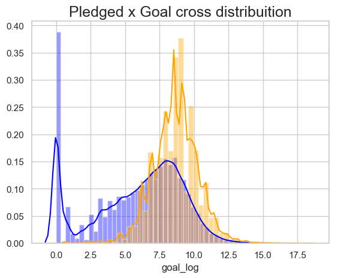

```python
# TODO referencias por color en la visualizacion
g = sns.distplot(projects_2017['pledged_log'], color='blue', label='pledged (log)')
g = sns.distplot(projects_2017['goal_log'], color='orange', label='goal (log)')
g.set_title("Pledged x Goal cross distribuition", fontsize=18)
```

## Analizando por Estado del proyecto

Otro aspecto que podriamos considerar es analizar los proyecto segun su estado final (variable categorica), para ello podemos sacar inicialmente algunas estadisticas que pueden servirnos para el analisis en relacion a su media y desvio.

```python
print("Calculando la media por estado final del proyecto")
print(round(projects_2017.groupby(["state"])["goal", "pledged"].mean(),2))
```

```
Calculando la media por estado final del proyecto
                           goal              pledged
state
canceled              76,293.96             2,317.80
failed                60,664.24             1,331.17
live                  84,039.95             6,352.72
successful             9,695.67            23,212.89
suspended            242,796.61            11,119.73
```

```python
print("Calculando el desvio standard por estado final del proyecto")
print(round(projects_2017.groupby(["state"])["goal", "pledged"].std(),2))
```

```
Calculando el desvio standard por estado final del proyecto
                           goal              pledged
state
canceled           1,295,688.35            12,830.64
failed             1,356,864.41             6,999.57
live               2,377,370.28            35,855.06
successful            28,790.07           160,709.99
suspended          4,239,279.71           120,736.14
```

## Boxplot

Una forma de ver esta misma informacion es utilizar una visualizacion conocida como boxplot. Usualmente usamos un boxplot para ver la distribucion de una variable numerica de acuerdo a una variable categorica (en este caso los distintos estados posibles de un proyecto).

```
Text(0,0.5,'Pledged (Log)')
```

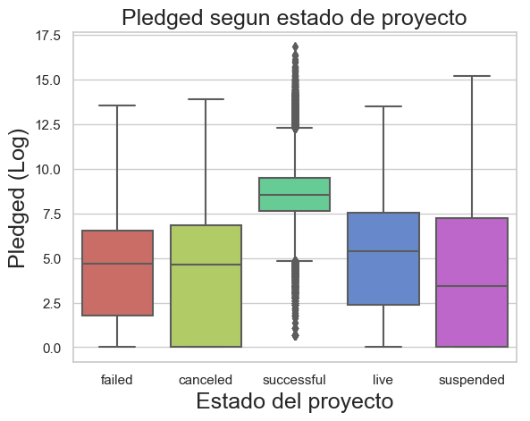

```python
# https://seaborn.pydata.org/generated/seaborn.boxplot.html
g = sns.boxplot(x="state", y="pledged_log",
                     data=projects_2017, palette="hls")
g.set_title("Pledged segun estado de proyecto", fontsize=18)
g.set_xlabel("Estado del proyecto", fontsize=18)
g.set_ylabel("Pledged (Log)", fontsize=18)
```

Para leerlo tenemos que considerar que la 'caja' del boxplot va desde el primer al tercer cuantil, es decir que el 25% de los datos estan por debajo de la caja y el 25% de los datos estan por encima de la caja. La caja concentra entonces el 50% de los datos. Las lıneas que salen de la caja van desde el primer cuantil hasta el valor minimo y maximo y los puntos son valores anomalos (outliers).

# Categoria com mayor cantidad de proyectos

Pasando a las variables categoricas podriamos querer analizar cuales son las categorias que tienen la mayor cantidad de proyectos.

```python
main_categories_counts = projects_2017["main_category"].value_counts()
main_categories_counts
```

```
Film & Video    51922
Music           43238
Publishing      31726
Games           24636
Art             22311
Design          21690
Technology      21556
Food            19941
Fashion         16584
Comics           8910
Theater          8709
Photography      7988
Crafts           6648
Journalism       3540
Dance            3228
Name: main_category, dtype: int64
```

## Bar Plot

Una forma de poder visualizar este tipo de informacion es utiliza un Bar Plot, de uso bastante popular y donde se cometen muchos errores. Algunas cosas que hay que tener en cuenta es que una de las variables a considerar debe ser categorica y por otro lado, los valores a evaluar deben comenzar en 0.

Existen otras variantes haciendo stacking de valores o directamente indicandolos en barras separadas de forma de que queden agrupados.

```
Text(0,0.5,'Name of Category')
```

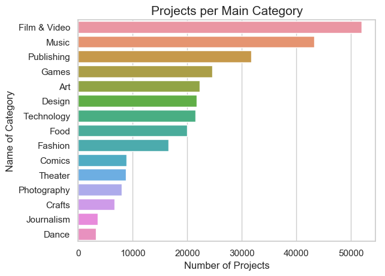

```python
# https://seaborn.pydata.org/generated/seaborn.barplot.html
g = sns.barplot(x=main_categories_counts.values, y=main_categories_counts.index, orient='h')
g.set_title("Projects per Main Category", fontsize=15)
g.set_xlabel("Number of Projects", fontsize=12)
g.set_ylabel("Name of Category", fontsize=12)
```

```
Text(0.5,1,'Projects per Main Category')
```

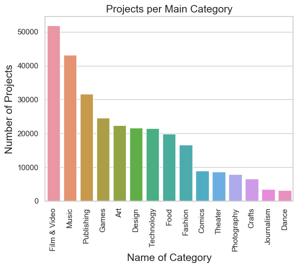

```python
# https://seaborn.pydata.org/generated/seaborn.countplot.html
# simplificacion para hacerlo via seaborn con countplot
g = sns.countplot(x='main_category', data=projects_2017, order=projects_2017['main_category'].value_counts().index, orient='v')
g.set_xticklabels(g.get_xticklabels(),rotation=90)
g.set_xlabel("Name of Category", fontsize=15)
g.set_ylabel("Number of Projects", fontsize=15)
g.set_title("Projects per Main Category", fontsize=15)
```

## Analisis Temporal

Para poder facilitar el analisis temporal de la informacion agregamos a nuestro data frame algunas columnas a partir del procesamiento de el valor de launched como datetime, y generamos algunas columnas para permitir agrupamientos por año, mes y dia de la semana.

```python
# procesamiento de fechas de lanzamiento en mes y año
projects_2017['launched'] = pd.to_datetime(projects_2017['launched'])
projects_2017['launch_month'] = projects_2017['launched'].dt.month
projects_2017['launch_year'] = projects_2017['launched'].dt.year
projects_2017['launch_weekday_name'] = projects_2017['launched'].dt.weekday_name
```

Para poder entender algunos aspectos de los datos, utilizamos [crosstab](https://pandas.pydata.org/pandas-docs/stable/generated/pandas.crosstab.html) para obtener una cross tabulacion de dos factores. Por default utiliza la frecuencia.

```python
#cantidades por estado y año
pd.crosstab(projects_2017.launch_year, projects_2017.state)
```

| state launch_year | canceled | failed | live | successful | suspended |
| --- | --- | --- | --- | --- | --- |
| 1970 | 6 | 0 | 0 | 0 | 0 |
| 2009 | 150 | 600 | 0 | 579 | 0 |
| 2010 | 926 | 4984 | 0 | 4593 | 16 |
| 2011 | 2144 | 11878 | 0 | 12171 | 44 |
| 2012 | 2572 | 20217 | 0 | 17706 | 52 |
| 2013 | 3025 | 18407 | 0 | 17201 | 54 |
| 2014 | 5288 | 28498 | 0 | 16811 | 172 |
| 2015 | 6165 | 31459 | 0 | 15451 | 468 |
| 2016 | 4608 | 20406 | 1 | 12803 | 212 |
| 2017 | 3427 | 15612 | 1657 | 11984 | 198 |
| 2018 | 0 | 0 | 82 | 0 | 0 |

## Grouped Bar Plot

Para visualizar esta informacion podemos crear un Grouped Bar Plot agrupando por el estado del proyecto

```
Text(0,0.5,'Cantidad de Proyectos')
```

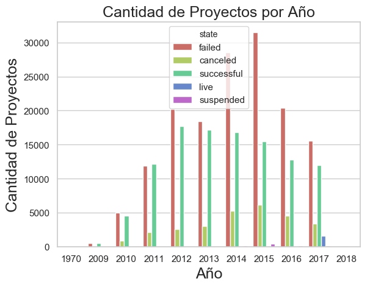

```python
g = sns.countplot(x="launch_year", hue="state", data=projects_2017, palette="hls")
g.set_title("Cantidad de Proyectos por Año", fontsize=18)
g.set_xlabel("Año", fontsize=18)
g.set_ylabel("Cantidad de Proyectos", fontsize=18)

# Nota: Stacked Bar Plot
# al creador de seaborn no le gustan los stacked http://randyzwitch.com/creating-stacked-bar-chart-seaborn/
# Investigar como realizarlo en https://matplotlib.org/gallery/lines_bars_and_markers/bar_stacked.html
```

Tambien podemos con la informacion temporal que tenemos analizar la distribucion de algunas de las variables continuas que consideramos temporalmente, por ejemplo la cantidad de dinero invertido en proyectos por los usuarios (pledged) por año.

```
Text(0,0.5,'Pledged (log)')
```

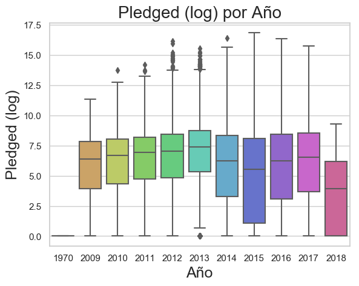

```python
g = sns.boxplot(x="launch_year", y="pledged_log",
                     data=projects_2017, palette="hls")
g.set_title("Pledged (log) por Año", fontsize=20)
g.set_xlabel("Año", fontsize=18)
g.set_ylabel("Pledged (log)", fontsize=18)
```

## Heatmap

Supongamos que tenemos un set de datos de la forma (name,variable,value) por ejemplo ("Año Lanzamiento de Proyecto", "Mes de Lanzamiento de Proyecto", "Goal del Proyecto") indicando que en el año 2017, en el mes de Marzo hubo un promedio de 76000 dolares por proyecto.

Un heatmap representa en el eje Y todos los puntos, instancias (años) y en el eje X cada una de las categorias posibles (meses en este caso). Los ejes suelen ser intercambiables sin que afecte la visualizacin.

El heatmap es entonces una matriz en donde cada celda muestra el valor que toma la variable del eje X para el punto del eje Y, tomando con valores de un cierto color cuando son mas altos y de otro cuando son mas bajos.

## Analizando Goal por Año y Mes

```python
# llevamos a una representacion de ese tipo usando una tabla pivot (se vera en detalle en la proxima clase).
# tener en cuenta que no puede haber valores duplicados por el indice por lo cual es necesario usar algun tipo
# funcion de agregacion
for_heatmap = projects_2017[projects_2017['state'] == 'successful'].pivot_table(index='launch_year', columns='launch_month', values='goal', aggfunc='mean')
```

```python
for_heatmap
```

| launch_month launch_year | 1 | 2 | 3 | 4 | 5 | 6 | 7 | 8 | 9 | 10 | 11 | 12 |
| --- | --- | --- | --- | --- | --- | --- | --- | --- | --- | --- | --- | --- |
| 2009 | nan | nan | nan | 2,074.45 | 1,847.47 | 2,557.92 | 3,240.94 | 4,033.57 | 4,265.79 | 3,457.29 | 3,582.78 | 4,022.15 |
| 2010 | 4,552.00 | 4,140.34 | 4,432.71 | 3,785.46 | 4,322.57 | 4,119.88 | 4,157.09 | 4,062.14 | 4,583.23 | 4,784.33 | 4,631.09 | 4,680.83 |
| 2011 | 4,332.52 | 4,773.10 | 4,749.70 | 5,035.03 | 5,338.26 | 5,548.37 | 5,083.20 | 4,930.93 | 5,651.80 | 5,481.88 | 6,333.65 | 5,837.98 |
| 2012 | 5,339.18 | 6,452.11 | 6,807.35 | 8,278.39 | 8,449.81 | 8,221.95 | 9,525.18 | 9,225.34 | 10,157.09 | 9,071.89 | 9,886.93 | 8,437.67 |
| 2013 | 9,247.06 | 9,100.23 | 11,537.99 | 13,141.98 | 11,834.06 | 10,703.79 | 11,626.44 | 9,611.95 | 12,344.80 | 12,600.22 | 10,936.47 | 10,674.37 |
| 2014 | 9,642.69 | 9,704.84 | 11,254.21 | 12,252.04 | 12,115.17 | 11,517.90 | 8,018.30 | 9,619.76 | 10,381.71 | 11,114.10 | 11,745.76 | 8,638.58 |
| 2015 | 11,210.08 | 12,448.05 | 10,229.98 | 10,740.50 | 12,383.39 | 13,812.12 | 12,435.24 | 11,320.63 | 12,790.27 | 13,287.19 | 13,812.54 | 8,097.25 |
| 2016 | 9,814.16 | 11,258.02 | 12,310.83 | 11,144.97 | 13,879.03 | 12,807.20 | 10,718.23 | 10,117.74 | 11,385.75 | 12,215.44 | 11,229.77 | 8,575.05 |
| 2017 | 7,956.56 | 11,381.47 | 9,389.22 | 10,751.59 | 12,066.70 | 11,196.82 | 11,001.64 | 10,224.00 | 11,512.53 | 11,114.63 | 9,100.36 | 4,463.64 |

```
Text(47.25,0.5,'Año de Lanzamiento del Proyecto')
```

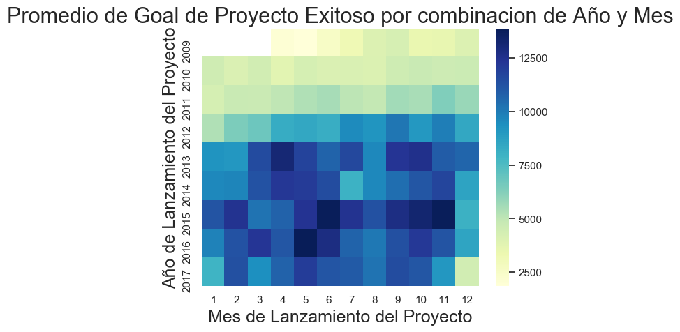

```python
# https://en.wikipedia.org/wiki/Kickstarter
# notar que segun la empresa de lanzo en 2009 en abril
# Launched April 28, 2009; 8 years ago
g = sns.heatmap(for_heatmap,  cmap="YlGnBu")
g.set_title("Promedio de Goal de Proyecto Exitoso por combinacion de Año y Mes", fontsize=22)
g.set_xlabel("Mes de Lanzamiento del Proyecto",fontsize=18)
g.set_ylabel("Año de Lanzamiento del Proyecto", fontsize=18)
```

```
Text(47.25,0.5,'Año de Lanzamiento del Proyecto')
```

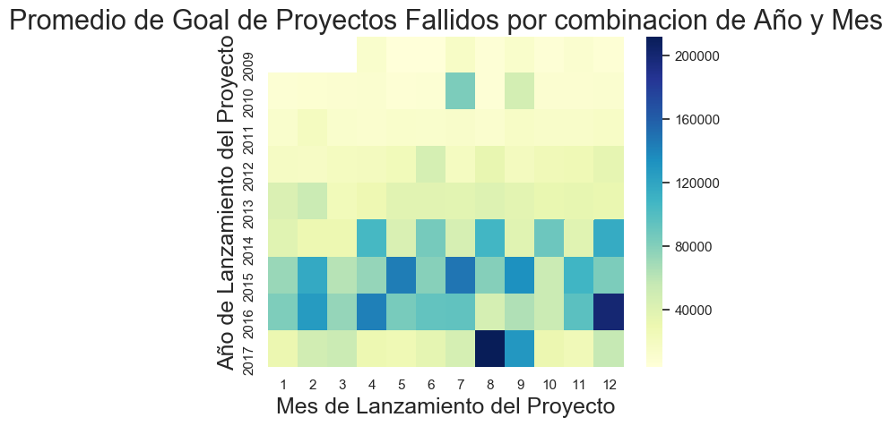

```python
# llevamos a una representacion de ese tipo usando una tabla pivot (se vera en detalle en la proxima clase).
# tener en cuenta que no puede haber valores duplicados por el indice por lo cual es necesario usar algun tipo
# funcion de agregacion
for_heatmap = projects_2017[projects_2017['state'] == 'failed'].pivot_table(index='launch_year', columns='launch_month', values='goal', aggfunc='mean')
g = sns.heatmap(for_heatmap,  cmap="YlGnBu")
g.set_title("Promedio de Goal de Proyectos Fallidos por combinacion de Año y Mes", fontsize=22)
g.set_xlabel("Mes de Lanzamiento del Proyecto",fontsize=18)
g.set_ylabel("Año de Lanzamiento del Proyecto", fontsize=18)
```

## Analizando Lanzamientos de proyectos por año y mes

```python
# generamos una columna para agregar y procesar mediante una tabla pivot
projects_2017['active_project'] = 1
for_heatmap = projects_2017.pivot_table(index='launch_year', columns='launch_month', values='active_project', aggfunc='sum')
```

```python
for_heatmap
```

| launch_month launch_year | 1 | 2 | 3 | 4 | 5 | 6 | 7 | 8 | 9 | 10 | 11 | 12 |
| --- | --- | --- | --- | --- | --- | --- | --- | --- | --- | --- | --- | --- |
| 1970 | 6.00 | nan | nan | nan | nan | nan | nan | nan | nan | nan | nan | nan |
| 2009 | nan | nan | nan | 19.00 | 74.00 | 75.00 | 78.00 | 115.00 | 348.00 | 194.00 | 218.00 | 208.00 |
| 2010 | 296.00 | 371.00 | 511.00 | 678.00 | 760.00 | 1,093.00 | 1,067.00 | 967.00 | 1,028.00 | 1,210.00 | 1,272.00 | 1,266.00 |
| 2011 | 1,594.00 | 1,803.00 | 2,025.00 | 2,243.00 | 2,288.00 | 2,294.00 | 2,368.00 | 2,320.00 | 2,151.00 | 2,311.00 | 2,612.00 | 2,228.00 |
| 2012 | 2,903.00 | 3,358.00 | 4,048.00 | 3,773.00 | 3,962.00 | 3,927.00 | 3,664.00 | 3,521.00 | 3,042.00 | 3,397.00 | 2,859.00 | 2,093.00 |
| 2013 | 2,919.00 | 2,980.00 | 3,404.00 | 3,549.00 | 3,748.00 | 3,398.00 | 3,458.00 | 3,108.00 | 3,057.00 | 3,454.00 | 3,280.00 | 2,332.00 |
| 2014 | 2,759.00 | 2,940.00 | 3,421.00 | 3,485.00 | 3,517.00 | 3,861.00 | 8,198.00 | 5,659.00 | 4,865.00 | 4,934.00 | 4,174.00 | 2,956.00 |
| 2015 | 4,955.00 | 5,603.00 | 5,988.00 | 5,489.00 | 4,810.00 | 4,588.00 | 4,033.00 | 3,871.00 | 3,936.00 | 3,839.00 | 3,817.00 | 2,614.00 |
| 2016 | 3,332.00 | 3,515.00 | 3,828.00 | 3,455.00 | 3,460.00 | 3,332.00 | 2,994.00 | 3,100.00 | 2,897.00 | 3,176.00 | 2,935.00 | 2,006.00 |
| 2017 | 2,929.00 | 2,588.00 | 3,284.00 | 2,739.00 | 2,980.00 | 2,864.00 | 2,752.00 | 2,838.00 | 2,532.00 | 2,873.00 | 2,809.00 | 1,690.00 |
| 2018 | 82.00 | nan | nan | nan | nan | nan | nan | nan | nan | nan | nan | nan |

```
Text(47.25,0.5,'Año de Lanzamiento del Proyecto')
```

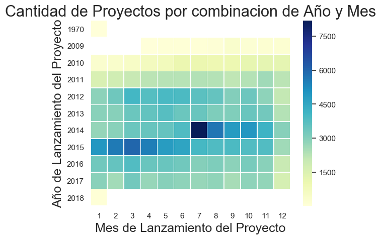

```python
g = sns.heatmap(for_heatmap, linewidths=.5, cmap="YlGnBu") # annot=True
g.set_title("Cantidad de Proyectos por combinacion de Año y Mes", fontsize=22)
g.set_xlabel("Mes de Lanzamiento del Proyecto",fontsize=18)
g.set_ylabel("Año de Lanzamiento del Proyecto", fontsize=18)
```